# Comparison of Oyster Size Distributions: EQIP vs. FHE vs. Natural

For this comparison, we will use a combination of oyster sampling through the EQIP and FHE monitoring projects.

The 3 treatments are:

- EQIP (est. 2008 - 2010)
- FHE (est. Fall 2015)
- Natural

The natural reefs are located in Foster Cove, while the FHE and EQIP reefs are located in the Northern and Southern portions of the Spawner Sanctuary within Ninigret Pond.

The purpose of this comparison is to investigate whether restoration reefs of different ages mimic naturally occuring reefs in the same water body, specifically regarding oyster length distribution

Let’s start by plotting histograms of the length distribution of each treatment:

This will give as an idea of how oysters are distributed by length.

## Histograms

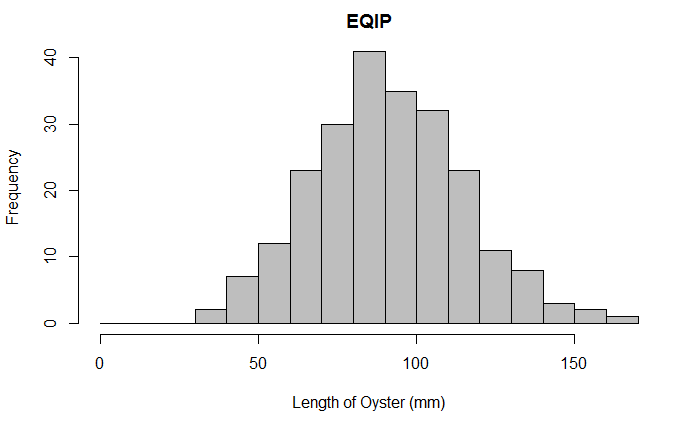

```r
# Create histograms
vec.breaks <- seq(from = 0, to = 170, by = 10) # set to 170 bc max length is 167
eqip.hist <- hist(subset(dat, Treatment == "EQIP")$Size.mm , breaks = vec.breaks,
                col = 'grey',
                xlab = 'Length of Oyster (mm)',
                ylab = 'Frequency',
                main = 'EQIP')
```

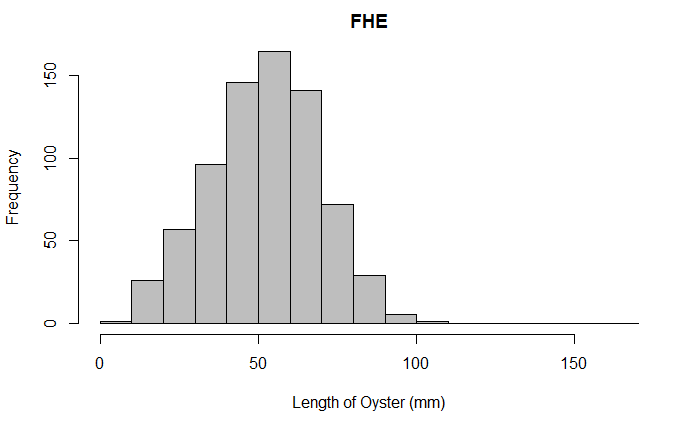

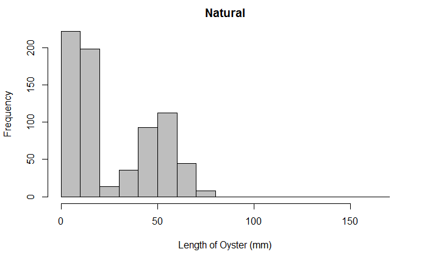

These histograms look different, but not entirely different. EQIP has a normal distribution with a bit of a tail to the right. FHE has a notmal distribution indicating one large size class with likely some recent recruits. Natural reefs reveal a definite recruiting class with 1-2 year oysters. The natural natural reefs are in unprotected waters, so their lack of >90mm oysters can be explained.

To start, let’s look at the proportion of the population that is composed of recruits. Typically, studies identify new recruits as individuals less than 25mm in length, so we will do the same.

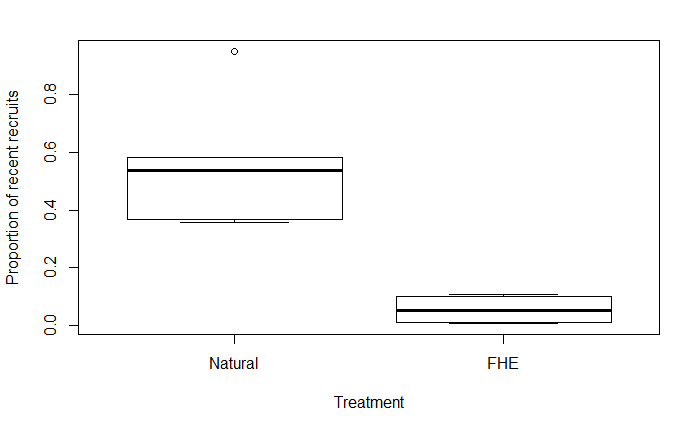

```r
library(plyr)
dat_prop <- count(dat, c("ID","Treatment"))
colnames(dat_prop)[3]<- 'Total.Count'
recruit_dat <- subset(dat, Size.mm < 25)
recruit_dat <- count(recruit_dat, c("ID","Treatment"))
colnames(recruit_dat)[3] <- "Rec.Count"
dat_prop <- merge(dat_prop, recruit_dat, by = c("ID","Treatment"), all = T)
# Remove EQIP bc there are no recruits
dat_prop <- subset(dat_prop, Treatment != "EQIP")
dat_prop$Treatment <- factor(dat_prop$Treatment)
dat_prop$Proportion <- dat_prop$Rec.Count/dat_prop$Total.Count
boxplot(dat_prop$Proportion ~ dat_prop$Treatment, xlab = "Treatment",
        ylab = "Proportion of recent recruits")
```

```r
print(dat_prop)
```

|  | ID | Treatment | Total.Count | Rec.Count | Proportion |
| --- | --- | --- | --- | --- | --- |
| 1 | FCNR1 | Natural | 295 | 159 | 0.538983051 |
| 2 | FCNR2 | Natural | 84 | 49 | 0.583333333 |
| 3 | FCNR3 | Natural | 30 | 11 | 0.366666667 |
| 4 | FCNR5 | Natural | 154 | 55 | 0.357142857 |
| 5 | FCNR6 | Natural | 165 | 157 | 0.951515152 |
| 17 | Nin-1S | FHE | 298 | 27 | 0.090604027 |
| 18 | Nin-2S | FHE | 112 | 12 | 0.107142857 |
| 19 | Nin-3S | FHE | 193 | 2 | 0.010362694 |
| 20 | Nin-4S | FHE | 136 | 1 | 0.007352941 |

It is interesting that one Natural reef is composed 95% of recent recruits

## Statistical Analysis

Mann-Whitney U test for non normal distributions:

```r
library(car)
aov_model <- aov(Proportion ~ Treatment, dat = dat_prop)
leveneTest(aov_model)
```

```
Levene's Test for Homogeneity of Variance (center = median)
      Df F value Pr(>F)
group  1  2.0637  0.194
       7
```

```r
wilcox.test(Proportion ~ Treatment, data=dat_prop)
```

```
    Wilcoxon rank sum test

data:  Proportion by Treatment
W = 20, p-value = 0.01587
alternative hypothesis: true location shift is not equal to 0
```

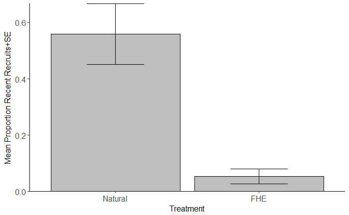

```r
library(sciplot)
library(ggplot2)
dat_mean <- aggregate(dat_prop$Proportion~dat_prop$Treatment, FUN = mean)
colnames(dat_mean) <- c("Treatment","Mean")
dat_se <- aggregate(dat_prop$Proportion~dat_prop$Treatment, FUN = se)
colnames(dat_se) <- c("Treatment", "SE")
dat_merge <- merge(dat_mean, dat_se, by = "Treatment")
prop_plot <- ggplot(dat_merge, aes(x=Treatment, y=Mean)) +
  geom_bar(position=position_dodge(), stat="identity",colour = "black", fill = "grey") +
  geom_errorbar(aes(ymin=Mean-SE, ymax=Mean+SE),
                width=.4,                    # Width of the error bars
                position=position_dodge(.9)) +
  ylab("Mean Proportion Recent Recruits+SE") +
  xlab("Treatment") +
  theme(axis.text = element_text(size = 12),legend.title=element_text(size=12),
        axis.title = element_text(size = 12),
        legend.text = element_text(size = 12),
        panel.grid.major = element_blank(),
        panel.grid.minor = element_blank(),
        panel.background = element_blank(),
        axis.line = element_line(colour = ("black"))) +
        scale_y_continuous(expand = c(0, 0))
prop_plot
```

## On second thought, recruitment Proportion is probably not the way to go…

# Recruitment Rate

## A look at recruitment rate may paint a better picture.

## Number of recruits per m2

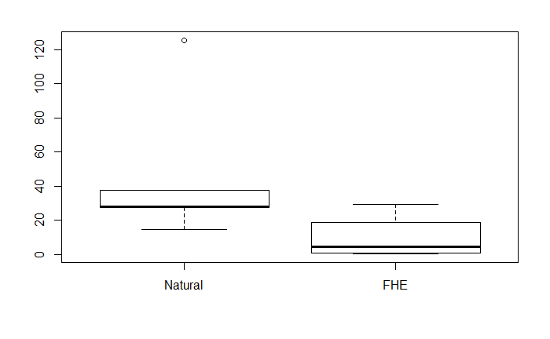

```r
eqip_quad <- eqip_quad[,c(2,3,8)]
fhe_quad <- subset(fhe_quad, Date.Collected > "2016-8-01")
fhe_quad <- fhe_quad[,c(1,4,8)]
colnames(fhe_quad)[1]<- "ID"
fhe_quad <- subset(fhe_quad, ID == "Nin-1S" | ID == "Nin-2S" | ID == "Nin-3S" | ID == "Nin-4S")
fhe_quad$Treatment <- factor("FHE")
total_per_quad <- count(dat, vars = c("ID","Quadrat.Number","Treatment"))
colnames(total_per_quad)[4]<- "Total.Measured"
recruits_per_quad <- subset(dat, Size.mm < 25)
recruits_per_quad <- count(recruits_per_quad, vars = c("ID","Quadrat.Number"))
colnames(recruits_per_quad)[3] <- "Recruits.Measured"
counts_per_quad <- merge(total_per_quad,recruits_per_quad, by = c("ID","Quadrat.Number"), all = T)
counts_per_quad <- subset(counts_per_quad, Treatment != "EQIP")
counts_per_quad$ID <- factor(counts_per_quad$ID)
counts_per_quad$Recruits.Measured[is.na(counts_per_quad$Recruits.Measured)] <- 0
all_counts <- merge(counts_per_quad, fhe_quad, by = c("ID","Quadrat.Number","Treatment"), all = T)
all_counts[is.na(all_counts)] <- 0
all_counts$Recruits.Adj <- ifelse(all_counts$Live.Oyster.Count != 0,
                                  (all_counts$Recruits.Measured *
                                    (all_counts$Total.Measured + all_counts$Live.Oyster.Count))/
                                    all_counts$Total.Measured,all_counts$Recruits.Measured)
rate_aggregate <- aggregate(all_counts$Recruits.Adj ~ all_counts$ID+all_counts$Treatment, FUN = mean)
colnames(rate_aggregate) <- c("ID","Treatment","Recruits.Adj")
rate_aggregate$Treatment <- factor(rate_aggregate$Treatment)
rate_aggregate$Recruits.Adj <- rate_aggregate$Recruits.Adj * 4 #to get rate /m2 rather than 1/4m2
boxplot(rate_aggregate$Recruits.Adj ~ rate_aggregate$Treatment)
```

This boxplot looks pretty ugly, but may perform well with some sort of log transformation

## Statistical Analysis

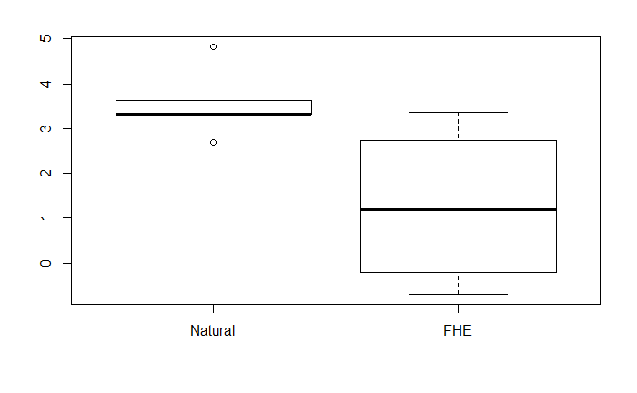

```r
rate_aggregate$Log.Recruitment <- log(rate_aggregate$Recruits.Adj)
boxplot(rate_aggregate$Log.Recruitment ~ rate_aggregate$Treatment)
```

```r
rate_model <- aov(rate_aggregate$Log.Recruitment ~ rate_aggregate$Treatment)
shapiro.test(rate_model$residuals)
```

```
    Shapiro-Wilk normality test

data:  rate_model$residuals
W = 0.98088, p-value = 0.9687
```

```r
leveneTest(rate_model)
```

```
Levene's Test for Homogeneity of Variance (center = median)
      Df F value  Pr(>F)
group  1  5.0975 0.05852 .
       7
---
Signif. codes:  0 ‘***’ 0.001 ‘**’ 0.01 ‘*’ 0.05 ‘.’ 0.1 ‘ ’ 1
```

Model satisfies assumptions of normality and variance (slightly)

```r
summary(rate_model)
```

```
                         Df Sum Sq Mean Sq F value Pr(>F)
rate_aggregate$Treatment  1  11.71  11.708   6.608  0.037 *
Residuals                 7  12.40   1.772
---
Signif. codes:  0 ‘***’ 0.001 ‘**’ 0.01 ‘*’ 0.05 ‘.’ 0.1 ‘ ’ 1
```

Results show statistical significance between treatments.

## Final Plot

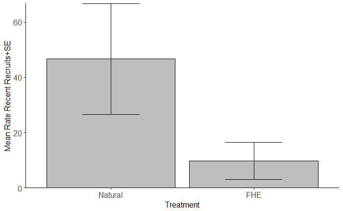

```r
rate_mean <- aggregate(rate_aggregate$Recruits.Adj~rate_aggregate$Treatment, FUN = mean)
colnames(rate_mean) <- c("Treatment","Mean")
rate_se <- aggregate(rate_aggregate$Recruits.Adj~rate_aggregate$Treatment, FUN = se)
colnames(rate_se) <- c("Treatment", "SE")
rate_merge <- merge(rate_mean, rate_se, by = "Treatment")
rate_plot <- ggplot(rate_merge, aes(x=Treatment, y=Mean)) +
  geom_bar(position=position_dodge(), stat="identity",colour = "black", fill = "grey") +
  geom_errorbar(aes(ymin=Mean-SE, ymax=Mean+SE),
                width=.4,                    # Width of the error bars
                position=position_dodge(.9)) +
  ylab("Mean Rate Recent Recruits+SE") +
  xlab("Treatment") +
  theme(axis.text = element_text(size = 12),legend.title=element_text(size=12),
        axis.title = element_text(size = 12),
        legend.text = element_text(size = 12),
        panel.grid.major = element_blank(),
        panel.grid.minor = element_blank(),
        panel.background = element_blank(),
        axis.line = element_line(colour = ("black"))) +
        scale_y_continuous(expand = c(0, 0))
rate_plot
```